# Analysis of Verizon Wireless and AT&T Stock Prices

Usman Dauda

13/02/2021

## Obtaining Stock Data

Here we create plots of Verizon Wireless and AT&T using the ‘quantmod’ library in R, which allows us to import stock prices by their ticker over a specified time period. In this case, the stock prices from Feb 1<sup>st</sup> 2013 till 2021 are used.

```r
# Obtain 8 years of stock data for Verizon Wireless
verizon_data = getSymbols("VZ", src = "yahoo", from = "2013-02-01", to = "2021-02-01", auto.assign = FALSE)
at_t_data = getSymbols("T", src = "yahoo", from = "2013-02-01", to = "2021-02-01", auto.assign = FALSE)
```

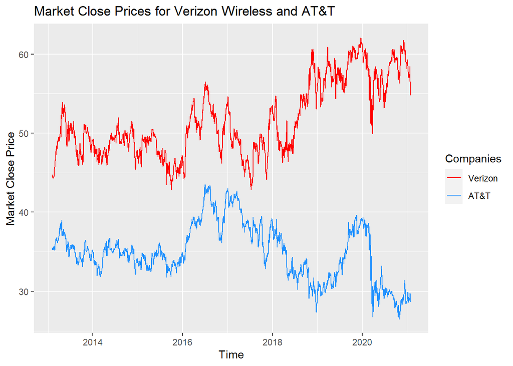

```r
# Plot Verizon Stock price over 8 year period
ggplot()+
  geom_line(mapping = aes(x = index(verizon_data$VZ.Close), y = as.double(verizon_data$VZ.Close), color = "Verizon")) +
  geom_line(mapping = aes(x = index(at_t_data$T.Close), y = as.double(at_t_data$T.Close), color = "AT&T")) +
  labs(x = "Time", y = "Market Close Price", title = "Market Close Prices for Verizon Wireless and AT&T") +
  scale_color_manual(name = legend, breaks = breaks,values = values)
```

The plot above shows similar trends for both stocks, as they are in the same industry after all. The similarity in the stock trends is lacking in mid-2018 through to late 2019, which might be explained by setbacks from the legal battle fought by AT&T-Time Warner during their [merger in June of 2018](https://variety.com/2018/biz/news/att-time-warner-stocks-doj-antitrust-ruling-1202843216/).

### Calculate and Plot Log Returns of Stocks

```r
# Calculate Log Returns for both Stocks
log_return = log(verizon_data$VZ.Close/lag.xts(verizon_data$VZ.Close))
verizon = list(log_return = as.double(log_return)[-1])
log_return = log(at_t_data$T.Close/lag.xts(at_t_data$T.Close))
at_t = list(log_return = as.double(log_return)[-1])
```

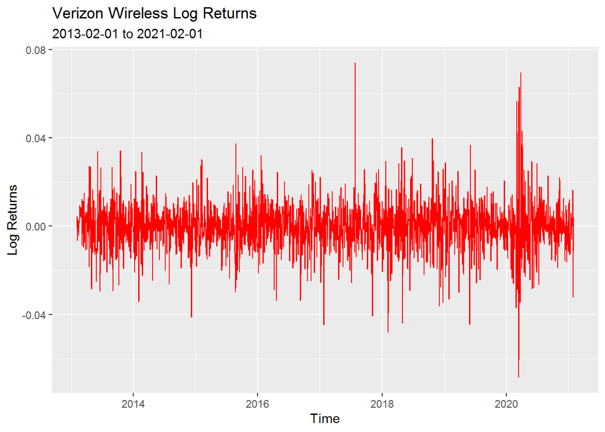

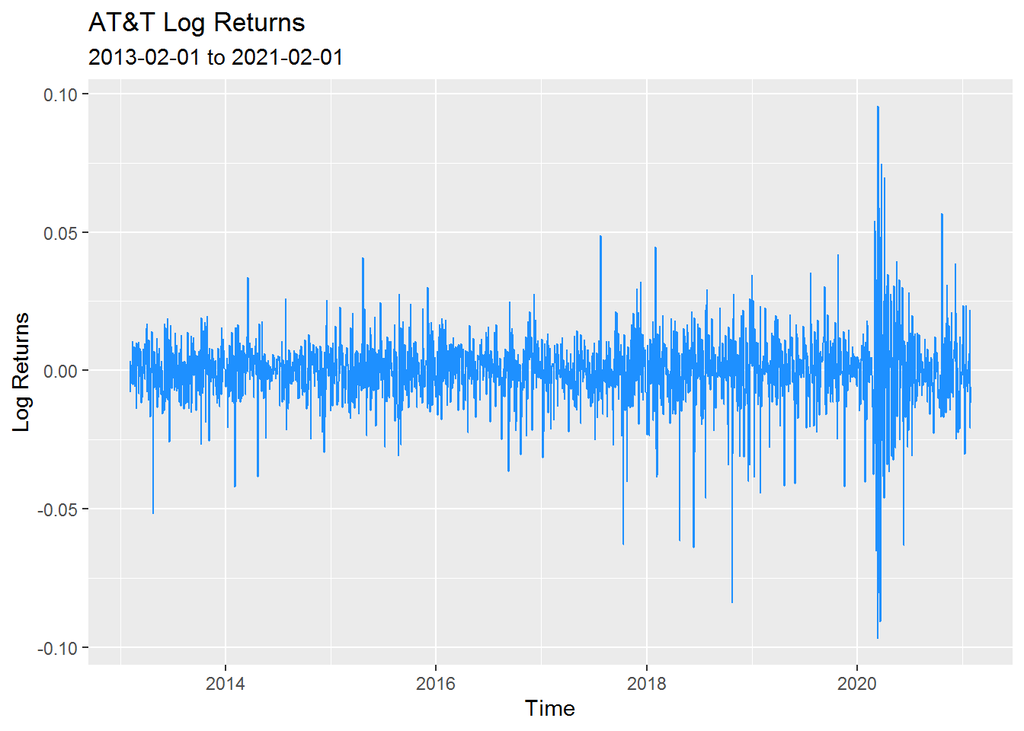

The log returns for both companies are centered on 0, and appear to be randomly distributed in value, a good indicator that a normal distribution can be used to model the log returns of the stock price.